Skip to contents

# Writing Excel workbooks with write_xlsx()

Source: [`vignettes/write-xlsx.Rmd`](https://github.com/yng-me/tsg/blob/v0.2.0/vignettes/write-xlsx.Rmd)

```r
library(tsg)
library(dplyr)
```

`write_xlsx()` turns a tsg table, or a list of tables, into a formatted Excel workbook. What the workbook looks like depends on the structure of the table you generated: a single table, a crosstab with merged headers, a list of tables, or a grouped list. This vignette goes through each structure and shows the result.

The screenshots are of the sheets as Microsoft Excel prints them.

## The big picture

```r
write_xlsx(
  data,                  # a tsg table, or a (nested) list of them
  path,                  # a file, or a folder when separate_files = TRUE
  title, subtitle,       # used when a table has none of its own
  source_note, footnotes,
  sheet_name,            # the sheet of a single table
  separate_files,        # one workbook per list item
  collapse_list,         # stack a list of tables on one sheet
  row_group_as_column,   # show group names as a column instead of titles
  include_table_list,    # add a "List of Tables" sheet
  table_list_reference,  # titles, numbers and notes kept in a data frame or file
  facade                 # the look: fonts, colours, borders
)
```

| You pass | You get |
| --- | --- |
| One table | One sheet |
| A list of tables | One sheet per table |
| A list with `collapse_list = TRUE` | All tables stacked on one sheet |
| A list with `separate_files = TRUE` | One workbook per table, in a folder |
| `group_as_list = TRUE` with one group | One sheet per group |
| `group_as_list = TRUE` with two or more groups | One sheet per first group, with the other groups as titles on that sheet |
| Any of these with `include_table_list = TRUE` | The same, plus a “List of Tables” sheet with links |

## One table

A frequency table is the simplest case: a header row, one row per category and a Total row. Titles and notes go above and below the table.

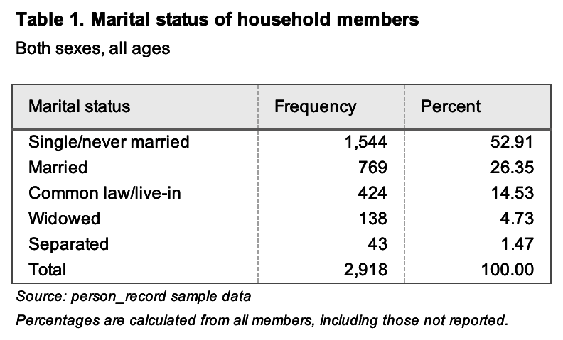

```r
frequency <- person_record |>
  generate_frequency(marital_status) |>
  add_table_title("Table 1. Marital status of household members") |>
  add_table_subtitle("Both sexes, all ages") |>
  add_source_note("Source: person_record sample data") |>
  add_footnote("Percentages are calculated from all members, including those not reported.")

write_xlsx(frequency, "frequency.xlsx")
```

The title, subtitle, source note and footnotes live on the table itself, so they travel with it. You can also pass `title`, `subtitle`, `source_note` and `footnotes` straight to `write_xlsx()`. A table’s own text always wins over the arguments.

`sheet_name` names the sheet (the default is `"Sheet1"`):

```r
write_xlsx(frequency, "frequency-named.xlsx", sheet_name = "Marital status")
openxlsx::getSheetNames("frequency-named.xlsx")
```

```
#> [1] "Marital status"
```

## A crosstab with merged headers

A crosstab has a two-level header: the variable (here `Frequency` and `Percent`) sits above the categories of the column variable. `write_xlsx()` writes this as merged header cells. The stub header (`Marital status`) and `Total` are merged downwards so they span both header rows.

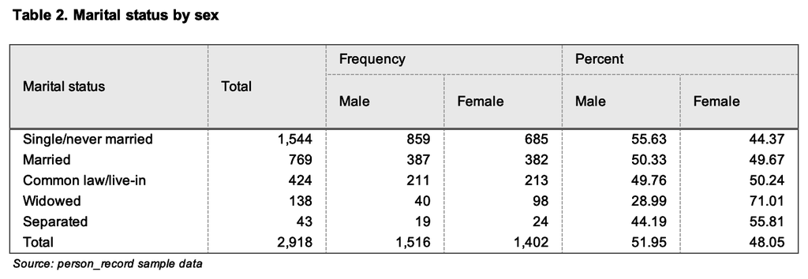

```r
crosstab <- person_record |>
  generate_crosstab(marital_status, sex) |>
  add_table_title("Table 2. Marital status by sex") |>
  add_source_note("Source: person_record sample data")

write_xlsx(crosstab, "crosstab.xlsx")
```

Header levels come from the column names, split at `names_separator` (`"__"` by default). If you build a table with your own column names, `"Frequency__Male"` becomes a `Frequency` header over a `Male` header.

### Several column variables side by side

With `collapse_list = TRUE`, `generate_crosstab()` puts the crosstabs against several column variables next to each other in one table. The header then has three levels: the variable, the statistic and the category.

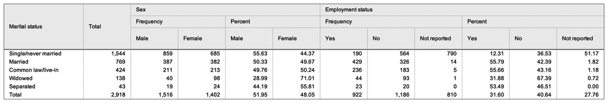

```r
side_by_side <- person_record |>
  generate_crosstab(marital_status, sex, employed, collapse_list = TRUE)

write_xlsx(side_by_side, "crosstab-multi.xlsx")
```

## A summary table

`generate_summary()` gives one row per numeric variable and one column per statistic.

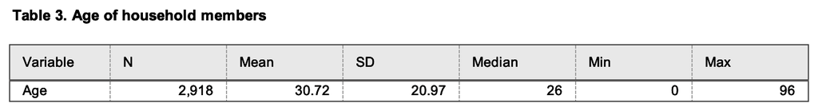

```r
summary_table <- person_record |>
  generate_summary(age, stats = c("n", "mean", "sd", "median", "min", "max")) |>
  add_table_title("Table 3. Age of household members")

write_xlsx(summary_table, "summary.xlsx")
```

## A list of tables: one sheet each

Give `write_xlsx()` a named list and every table gets its own sheet, named after the list item.

```r
tables <- list(
  Sex = generate_frequency(person_record, sex),
  Marital = generate_frequency(person_record, marital_status),
  Employment = generate_crosstab(person_record, employed, sex)
)

write_xlsx(tables, "tables.xlsx")
openxlsx::getSheetNames("tables.xlsx")
```

```
#> [1] "Sex"        "Marital"    "Employment"
```

Calling `generate_frequency()` with several variables returns such a list, named by the variable labels, so you can write it directly:

```r
several <- generate_frequency(person_record, sex, employed, seeing)
names(several)
```

```
#> [1] "Sex"                             "Employment status"
#> [3] "Seeing, even if wearing glasses"
```

```r
long_names <- generate_frequency(person_record, hearing, walking)
names(long_names)
```

```
#> [1] "Hearing, even if using hearing aid"
#> [2] "Walking or climbing steps, even if with cane or artificial leg"
```

```r
write_xlsx(long_names, "long-names.xlsx", trim_sheet_names = TRUE)
openxlsx::getSheetNames("long-names.xlsx")
```

```
#> [1] "Hearing, even if using hearing"  "Walking or climbing steps, even"
```

When you pass `title` to a list, each sheet gets `"<title>: <sheet name>"` unless the table already has a title of its own:

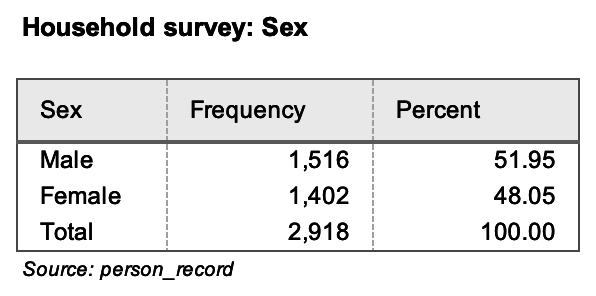

```r
write_xlsx(tables, "tables-titled.xlsx", title = "Household survey", source_note = "Source: person_record")
```

### All tables on one sheet

Use `collapse_list = TRUE` to stack the tables on a single sheet, each under its own heading. This is handy for a quick overview or for pasting into a document.

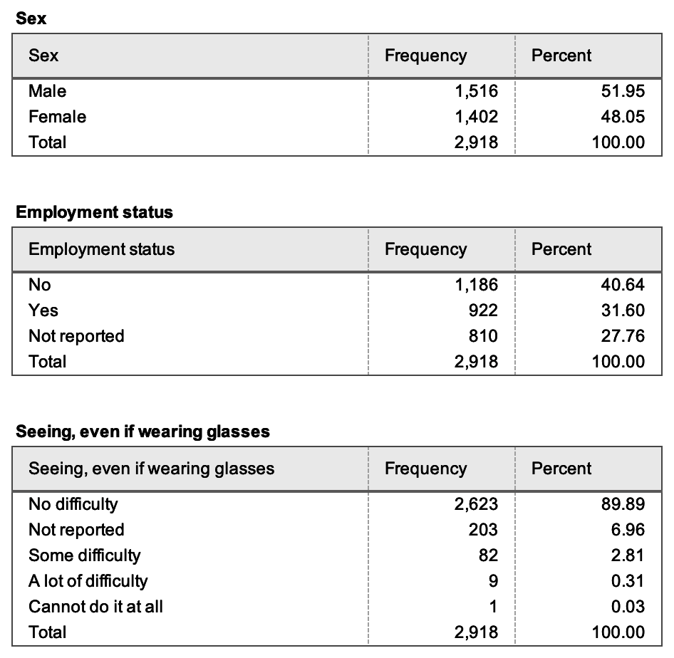

```r
write_xlsx(several, "stacked.xlsx", collapse_list = TRUE)
```

### One workbook per table

With `separate_files = TRUE`, `path` is a folder and each list item becomes a workbook named after it.

```r
write_xlsx(tables, "separate", separate_files = TRUE)
list.files("separate")
```

```
#> [1] "Employment.xlsx" "Marital.xlsx"    "Sex.xlsx"
```

## Grouped tables

Group the data with `dplyr::group_by()` and `generate_*()` can return one table per group. How `write_xlsx()` lays them out depends on how many groups there are.

### One group: one sheet per group

```r
by_sex <- person_record |>
  group_by(sex) |>
  generate_frequency(marital_status, group_as_list = TRUE)

names(by_sex)
```

```
#> [1] "Male"   "Female"
```

```r
write_xlsx(by_sex, "group-list.xlsx")
openxlsx::getSheetNames("group-list.xlsx")
```

```
#> [1] "Male"   "Female"
```

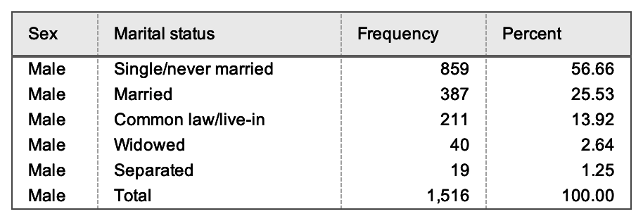

### Groups in one table

Without `group_as_list`, the group is a column and the groups sit under each other in a single table. With `group_as_hierarchy = TRUE` there is also an `All` block for the whole data.

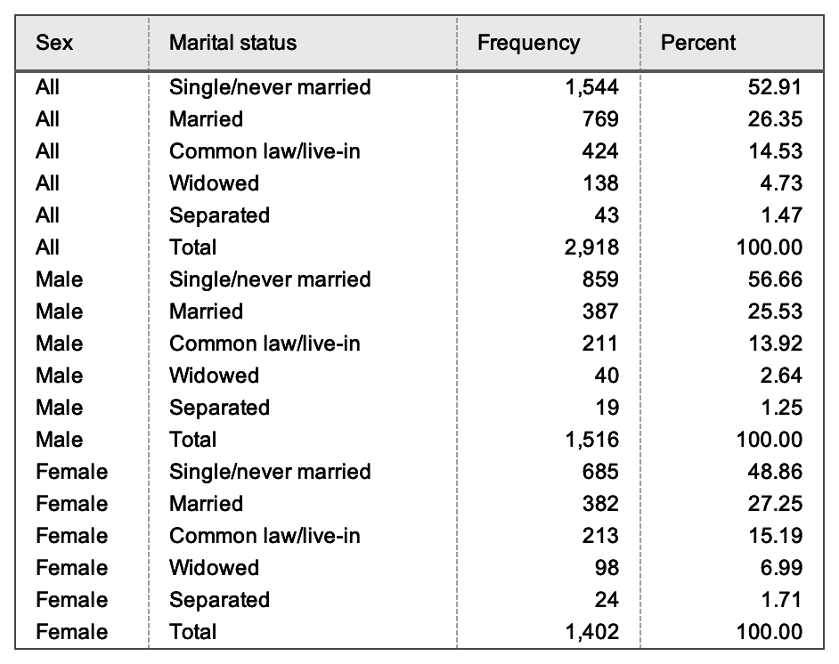

```r
hierarchy <- person_record |>
  group_by(sex) |>
  generate_frequency(marital_status, group_as_hierarchy = TRUE)

write_xlsx(hierarchy, "hierarchy.xlsx")
```

### Two or more groups: titles inside the sheet

With two groups, the first group gets a sheet each, and the second group becomes a title above its own block of rows. A third group would add a second level of titles, named by their path, such as `"Yes - No difficulty"`.

```r
nested <- person_record |>
  group_by(sex, employed) |>
  generate_frequency(marital_status, group_as_list = TRUE)

write_xlsx(nested, "nested.xlsx")
openxlsx::getSheetNames("nested.xlsx")
```

```
#> [1] "Male"   "Female"
```

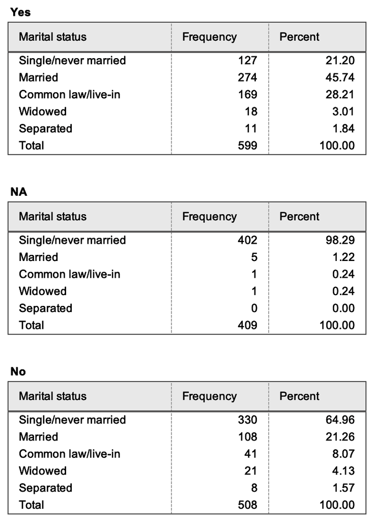

### All groups on one sheet

To keep the groups together, write a one-group list with `collapse_list = TRUE`. The groups then share one header, and each group gets a title row above its rows.

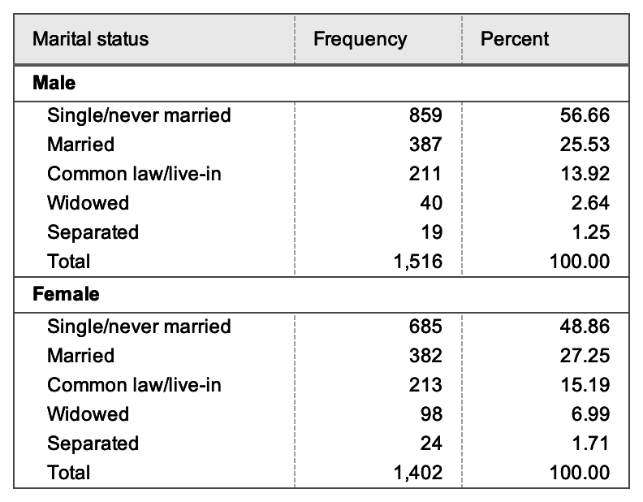

```r
write_xlsx(by_sex, "group-one-sheet.xlsx", collapse_list = TRUE)
```

### Group names as a column

A title row is awkward if you want to filter or sort the sheet in Excel. With `row_group_as_column = TRUE` the group names become the first column instead.

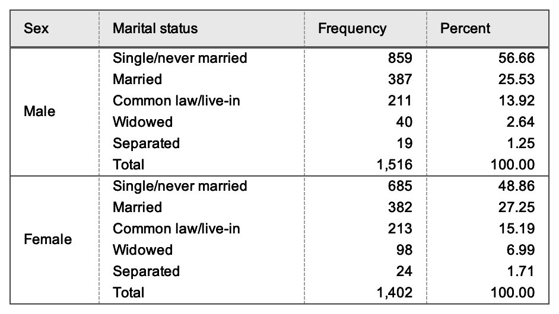

```r
write_xlsx(by_sex, "group-column.xlsx", collapse_list = TRUE, row_group_as_column = TRUE)
```

It works the same on the sheets of a list with two or more groups: each sheet gets one column per group.

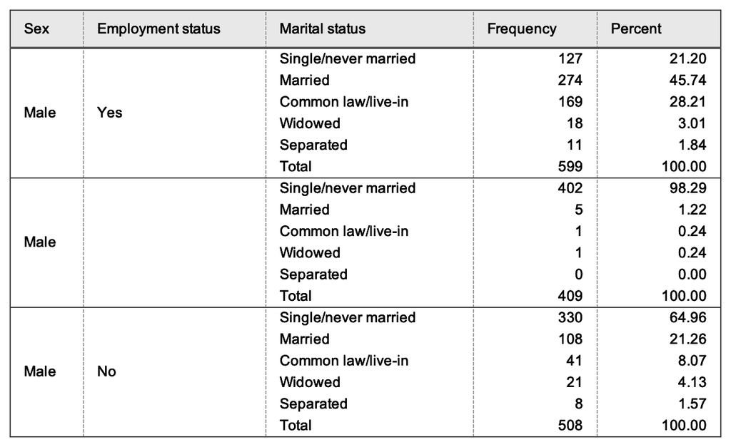

```r
write_xlsx(nested, "nested-column.xlsx", row_group_as_column = TRUE)
```

## A table list: an index sheet with links

Set `include_table_list = TRUE` to add a first sheet, `List of Tables`, with one row per table. The tab names are links to the sheets, and each table sheet gets a link back.

```r
write_xlsx(tables, "indexed.xlsx", include_table_list = TRUE)
openxlsx::getSheetNames("indexed.xlsx")
```

```
#> [1] "List of Tables" "Sex"            "Marital"        "Employment"
```

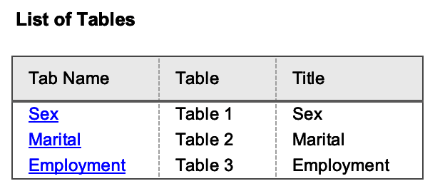

Without a reference, the table numbers follow the list order, and each title is the table’s own title, or its list name when it has none.

### Keeping titles and numbers in a reference table

In a long report, titles, table numbers and notes are easier to manage in one place than spread through the code. Give `table_list_reference` a data frame (or the path to a `.csv`, `.json` or `.xlsx` file) with one row per table.

| Column | Meaning |
| --- | --- |
| `table_id` | The **name of the list item**. This is how a row finds its table. |
| `table_name` | The sheet name, also shown in the index. |
| `table_number` | The number in the index and in the title (`1` becomes “Table 1.”). |
| `title` | The title above the table. |
| `subtitle`, `source_note`, `footnotes` | Optional. They replace the table’s own text. |

```r
reference <- data.frame(
  table_id = c("Sex", "Marital", "Employment"),
  table_name = c("By sex", "By marital status", "Employment by sex"),
  table_number = 1:3,
  title = c(
    "Household members by sex",
    "Household members by marital status",
    "Employment status by sex"
  ),
  subtitle = c(NA, NA, "Persons with a reported status"),
  source_note = "Source: person_record sample data",
  footnotes = NA
)

write_xlsx(
  tables,
  "reference.xlsx",
  include_table_list = TRUE,
  table_list_reference = reference
)

openxlsx::getSheetNames("reference.xlsx")
```

```
#> [1] "List of Tables"    "By sex"            "By marital status"
#> [4] "Employment by sex"
```

The index lists the tables by their `table_name` and number:

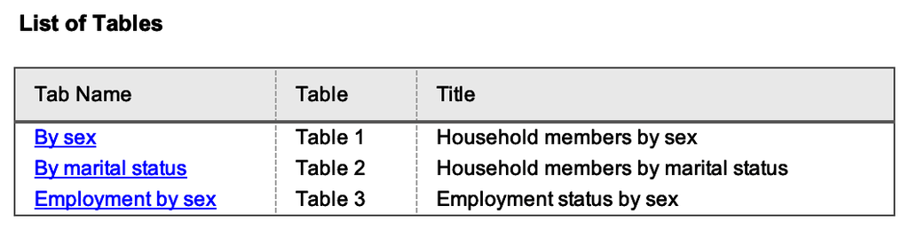

Each table sheet is named by `table_name`. The title is prefixed with the table number, and the subtitle and source note come from the reference:

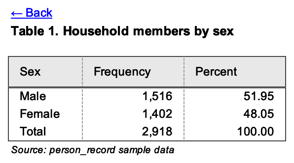

### From a file

The reference can be a file, so someone who does not write R can edit titles and numbers. `generate_template()` writes an empty one with the right columns:

```r
generate_template("table-list.xlsx", template = "table-list")
```

```r
write.csv(reference, "table-list.csv", row.names = FALSE)

write_xlsx(
  tables,
  "reference-file.xlsx",
  include_table_list = TRUE,
  table_list_reference = "table-list.csv"
)
```

A few rules worth knowing:

- Only the tables whose `table_id` is in the reference are looked up. A table with no row keeps its own title and its list name as the sheet name.
- A row whose `table_id` matches no list item is ignored.
- `table_id` must match the list names exactly, so name your list items.
- `table_list_reference` only has an effect together with `include_table_list = TRUE`.

## Changing the look

The look of a workbook is a facade: fonts, fills, borders and column widths. Pass a built-in one by name:

```r
crosstab_plain <- person_record |>
  generate_crosstab(marital_status, sex) |>
  add_table_title("Marital status by sex")

write_xlsx(crosstab_plain, "booktabs.xlsx", facade = "booktabs")
write_xlsx(crosstab_plain, "financial.xlsx", facade = "financial")
write_xlsx(crosstab_plain, "dark.xlsx", facade = "dark")
```

`"booktabs"`: a thick rule on top and bottom, a thin one under the header.

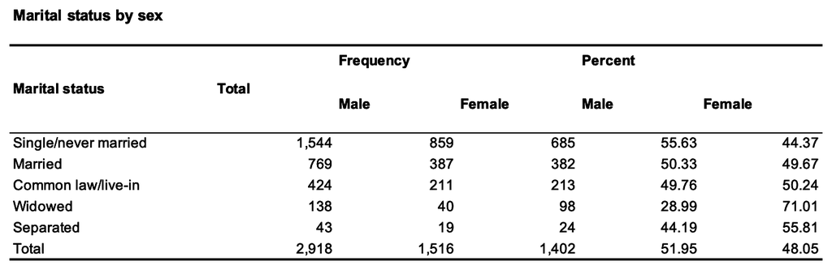

`"financial"`: a dark header, a thin grid and a bold last row.

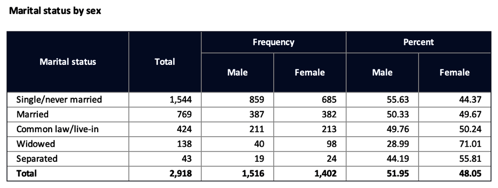

`"dark"`: light text on a dark background.

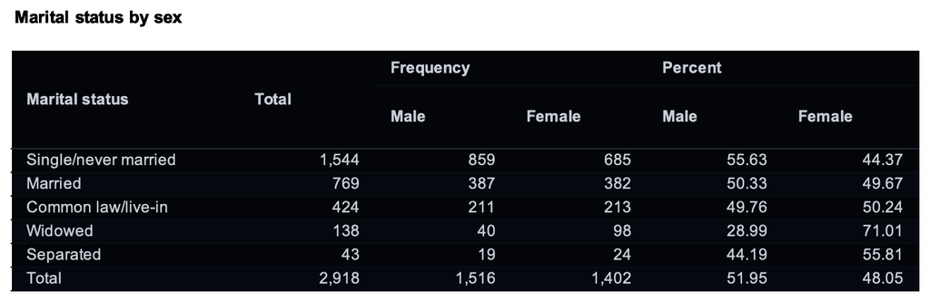

To change one table only, use `add_facade()`. It takes precedence over the `facade` argument of `write_xlsx()`:

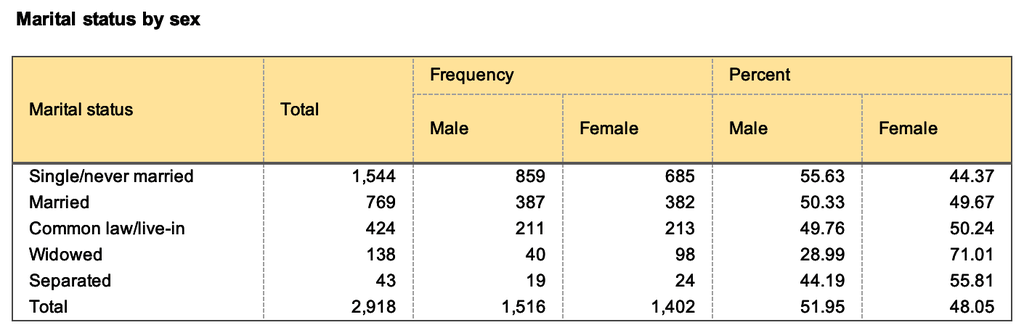

```r
crosstab_plain |>
  add_facade(header.fgFill = "#FFF2CC", table.offsetRow = 1, table.offsetCol = 1) |>
  write_xlsx("offset.xlsx")
```

The same facades style HTML, PDF and Word output. All the facade settings and the full list of built-in styles are in `vignette("facade")`.

## Passing options to openxlsx

Extra arguments in `...` go to `openxlsx::createWorkbook()` (such as `creator`) or `openxlsx::addWorksheet()` (such as `zoom`), matched by name:

```r
write_xlsx(frequency, "options.xlsx", creator = "Survey Unit", zoom = 120)
```

## Where to go next

- `vignette("facade")` for styles and every facade setting.
- `vignette("output-formats")` for HTML, PDF and Word.
- `vignette("google-sheets")` to send the same workbook to Google Sheets.